# Data Visualization

- There are a large number of Python data visualization libraries. Overviews can be found at https://pyviz.org.

| Name | Year | PyPI DLs Dec. 2021 | Static Images or Interactive Web | Characteristics |
| --- | --- | --- | --- | --- |
| Matplotlib | 2003 | 25 M | Static Images | Low level commands. Based on MATLAB. Versatile. Basis for other programs. |
| Pandas | 2008 | 70 M | Static Images | Primarily for data handling with dataframes. Very basic plots. |
| Seaborn | 2012 | 8 M | Static Images | Based on Pandas and Matplotlib. Must use Matplotlib to change Seaborn defaults. |
| Bokeh | 2012 | 2 M | Interactive Web | Based on Grammar of Graphics. Lower level than Plotly and Altair. Supported by Anaconda, but open source. |
| Plotly | 2013 | 8 M | Interactive Web | Good for 3D graphs. Based on plotly.js. Has high level commands and optional low level commands. Both open and closed source. |
| Holoviews | 2015 | 0.2 M | Interactive Web | Based on Bokeh and Matplotlib. Higher level than Bokeh. |
| Altair | 2016 | 4 M | Interactive Web | Based on Vega. Unique data structure. Performs slower when over 5,000 records. |
| Plotnine | 2017 | 0.2 M | Static Images | Based on Grammar of Graphics. Python implementation of ggplot. Replaces the no-longer-maintained `ggplot` Python library. |

[figure not shown]

## Matplotlib

- **Matplotlib**--low level code for static image data visualization created in 2003
- Many other data visualization libraries, like Seaborn, are built on top of Matplotlib
- Matplotlib uses the NumPy array for input data
- The components of a Matplotlib plot are:

[figure not shown]

- **Figure**--instance of class `plt.Figure`. Like a single container that contains all the objects representing axes, graphics, text, and labels. Object commonly assigned name `fig`.
- **Axes**--instance of class `plt.Axes`. What we see inside a bounding box with ticks and labels. Object commonly assigned name `ax`.

[figure not shown]

- Matplotlib provides two distinct interfaces:
  1. MATLAB-style--tools within pyplot module. Said to be **stateful**. It keeps track of current figure and axes, upon which all pyplot commands are applied. Most convenient for very simple plots.
  2. OOP-style--create figure and axes objects. Methods are applied to these objects. Most convenient for more complex plots.

[figure not shown]

[output not shown]

**EXAMPLES**

```python
import matplotlib.pyplot as plt
```

**Blank Plot**

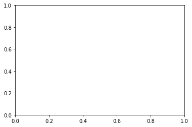

```python
fig = plt.figure()
ax = plt.axes()
```

## Seaborn

- **Seaborn**--high level code for static image data visualization built on top of Matplotlib
- Matplotlib is a powerful and flexible library. However it requires a lot of low level boiler plate code. We'll use Seaborn where possible and only use Matplotlib as needed.
- "While you can be productive using only seaborn functions, full customization of your graphics will require some knowledge of matplotlib’s concepts and API. One aspect of the learning curve for new users of seaborn will be knowing when dropping down to the matplotlib layer is necessary to achieve a particular customization"

### Data Input

- Seaborn accepts multiple data types such as NumPy arrays, Pandas data frames, and Python lists and dictionaries. Seaborn accepts tidy, "longform" data where each column is a variable and each row is a record. This is similar to R's ggplot2. Seaborn also accepts, "wideform" data stored in two-way tables, but the function calls would use different arguments. Using tidy data is recommended.

[figure not shown]

| Code | Use |
| --- | --- |
| `import seaborn as sns` | Conventionally imported as `sns` |
| `sns.load_dataset("<DATASET>")` | Return specified pandas data frame. Seaborn contains about a dozen data sets that can be used for examples. |

**EXAMPLES**

```python
import seaborn as sns
```

**Load Pandas Dataframe**

```python
penguins = sns.load_dataset("penguins")
print(type(penguins))
print(penguins.head())
```

```
<class 'pandas.core.frame.DataFrame'>
  species     island  bill_length_mm  bill_depth_mm  flipper_length_mm  \
0  Adelie  Torgersen            39.1           18.7              181.0
1  Adelie  Torgersen            39.5           17.4              186.0
2  Adelie  Torgersen            40.3           18.0              195.0
3  Adelie  Torgersen             NaN            NaN                NaN
4  Adelie  Torgersen            36.7           19.3              193.0

   body_mass_g     sex
0       3750.0    Male
1       3800.0  Female
2       3250.0  Female
3          NaN     NaN
4       3450.0  Female
```

```python
flights = sns.load_dataset("flights")
print(type(flights))
print(flights.head())
```

```
<class 'pandas.core.frame.DataFrame'>
   year month  passengers
0  1949   Jan         112
1  1949   Feb         118
2  1949   Mar         132
3  1949   Apr         129
4  1949   May         121
```

### Levels

- Seaborn plots can be created using two different "levels". There are subtle differences:
1. **Axes Level**--functions apply to Matplotlib axes object
   - Legend placed inside plot
   - Slightly shorter because of legend placement
   - Can be composed with other plots
   - "The axes-level functions call matplotlib.pyplot.gca() internally, which hooks into the matplotlib state-machine interface so that they draw their plots on the “currently-active” axes. But they additionally accept an ax= argument, which integrates with the object-oriented interface and lets you specify exactly where each plot should go:"

[figure not shown]

1. **Figure Level**--functions apply to Matplotlib figure object
   - Legend placed outside plot
   - Slightly taller because of legend placement
   - Can create plots with multiple subplots. This is called **faceting**.
   - "The figure-level functions wrap their axes-level counterparts and pass the kind-specific keyword arguments (such as the bin size for a histogram) down to the underlying function. That means they are no less flexible, but there is a downside: the kind-specific parameters don’t appear in the function signature or docstrings"

[figure not shown]

- "On balance, the figure-level functions add some additional complexity that can make things more confusing for beginners, but their distinct features give them additional power. The tutorial documentation mostly uses the figure-level functions, because they produce slightly cleaner plots, and we generally recommend their use for most applications. The one situation where they are not a good choice is when you need to make a complex, standalone figure that composes multiple different plot kinds. At this point, it’s recommended to set up the figure using matplotlib directly and to fill in the individual components using axes-level functions."
- Two functions do not fit into the scheme above. These are:
  1. `jointplot()`--figure level create subplots with JointGrid objects
  2. `pairplot()`--figure level create subplots with PairGrid objects

### Relplot

[output not shown]

**EXAMPLES**

```python
sns.set_theme(style="whitegrid")  # Prettier than default.  Explained later.
```

**Scatterplot**

```python
sns.relplot(kind="scatter", data=penguins, x="flipper_length_mm", y="body_mass_g")
plt.show()
```

[output not shown]

**Scatterplot with Style**

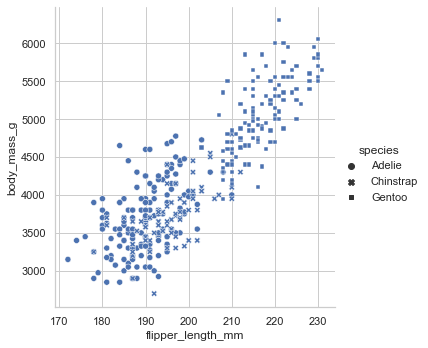

```python
sns.relplot(kind="scatter", data=penguins, x="flipper_length_mm", y="body_mass_g", style="species")
plt.show()
```

**Scatterplot with Categorical Hue**

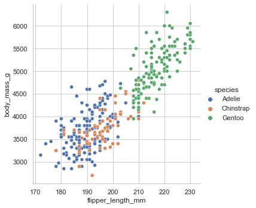

```python
sns.relplot(kind="scatter", data=penguins, x="flipper_length_mm", y="body_mass_g", hue="species")
plt.show()
```

**Scatterplot with Numerical Hue**

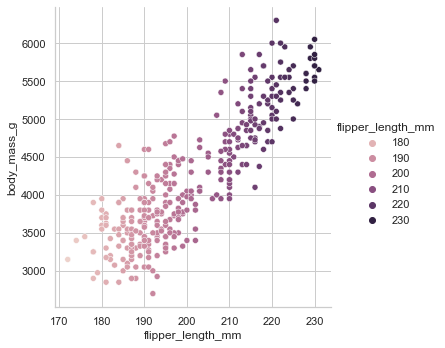

```python
sns.relplot(kind="scatter", data=penguins, x="flipper_length_mm", y="body_mass_g", hue="flipper_length_mm")
plt.show()
```

**Scatterplot with Categorical Size**

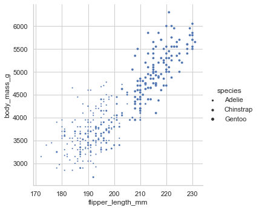

```python
sns.relplot(
    kind="scatter",
    data=penguins,
    x="flipper_length_mm",
    y="body_mass_g", size="species",
    sizes={"Adelie":5, "Chinstrap":10, "Gentoo":15}
)
plt.show()
```

**Scatterplot with Numerical Size**

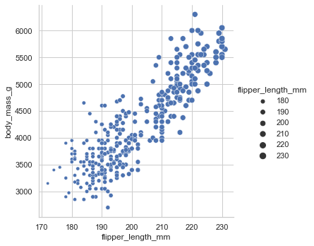

```python
sns.relplot(
    kind="scatter",
    data=penguins,
    x="flipper_length_mm",
    y="body_mass_g", size="flipper_length_mm",
)
plt.show()
```

**Line Plot**

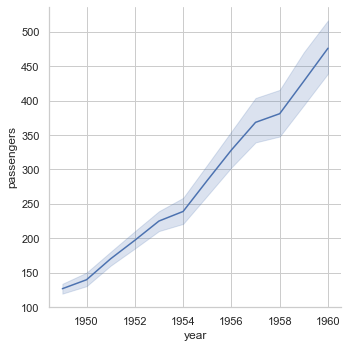

```python
sns.relplot(kind="line", data=flights, x="year", y="passengers")
plt.show()
```

**Line Plot with Hue and Style**

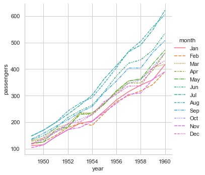

```python
sns.relplot(kind="line", data=flights, x="year", y="passengers", hue="month", style="month")
plt.show()
```

### Displot

[output not shown]

**EXAMPLES**

**Histogram**

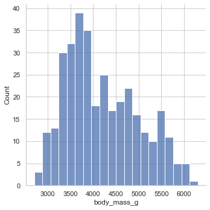

```python
sns.displot(kind="hist", data=penguins, x="body_mass_g", bins=20)
plt.show()
```

**Histogram with KDE**

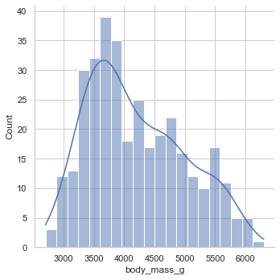

```python
sns.displot(kind="hist", data=penguins, x="body_mass_g", bins=20, kde=True)  # Add KDE to historgram
plt.show()
```

**KDE Plot**

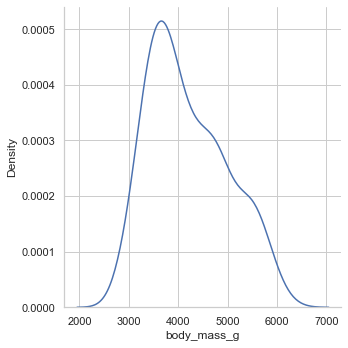

```python
sns.displot(kind="kde", data=penguins, x="body_mass_g")
plt.show()
```

**KDE Plot with Hue**

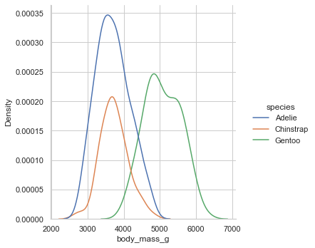

```python
sns.displot(kind="kde", data=penguins, x="body_mass_g", hue="species")
plt.show()
```

**ECDF Plot**

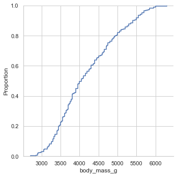

```python
sns.displot(kind="ecdf", data=penguins, x="body_mass_g")
plt.show()
```

### Catplot

[output not shown]

**EXAMPLES**

**Box Plot**

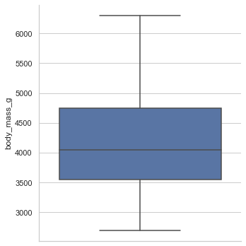

```python
sns.catplot(kind="box", data=penguins, y="body_mass_g")
plt.show()
```

**Box Plot with Categorical Variable**

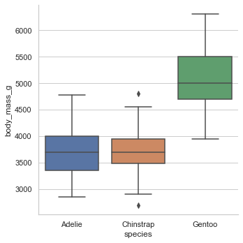

```python
sns.catplot(kind="box", data=penguins, x="species", y="body_mass_g")
plt.show()
```

**Box Plot with Categorical Variable and Hue**

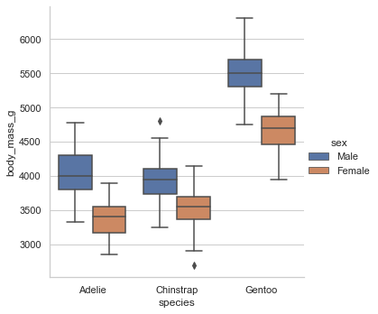

```python
sns.catplot(kind="box", data=penguins, x="species", y="body_mass_g", hue="sex")
plt.show()
```

**Violin Plot**

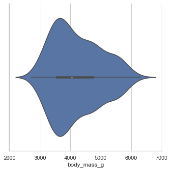

```python
sns.catplot(kind="violin", data=penguins, x="body_mass_g")
plt.show()
```

**Violin Plot with Categorical Variable**

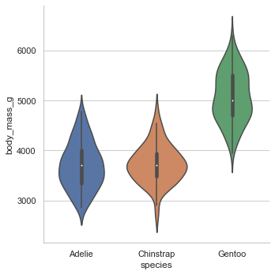

```python
sns.catplot(kind="violin", data=penguins, x="species", y="body_mass_g")
plt.show()
```

**Violin Plot with Categorical Variable and Hue**

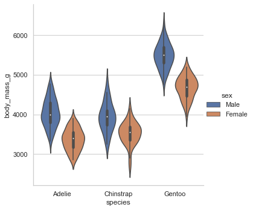

```python
sns.catplot(kind="violin", data=penguins, x="species", y="body_mass_g", hue="sex")
plt.show()
```

**Count Plot**

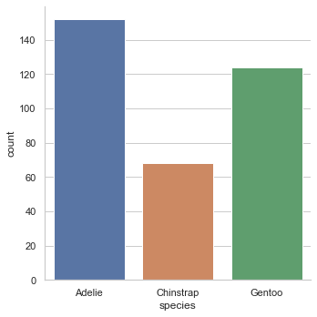

```python
sns.catplot(kind="count", data=penguins, x="species")
plt.show()
```

**Count Plot with Hue**

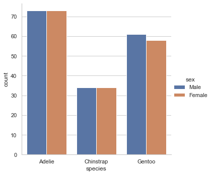

```python
sns.catplot(kind="count", data=penguins, x="species", hue="sex")
plt.show()
```

**Bar Plot**

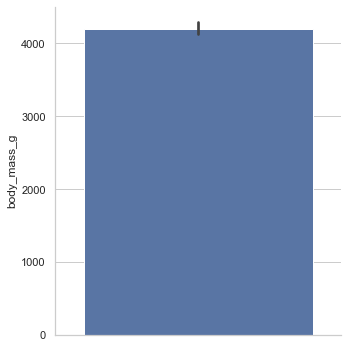

```python
sns.catplot(kind="bar", data=penguins, y="body_mass_g")
plt.show()
```

**Bar Plot with Categorical Variable**

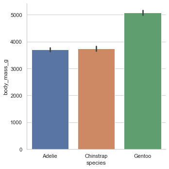

```python
sns.catplot(kind="bar", data=penguins, x="species", y="body_mass_g")
plt.show()
```

**Bar Plot with Categorical Variable and Hue**

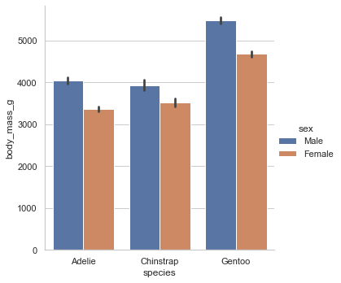

```python
sns.catplot(kind="bar", data=penguins, x="species", y="body_mass_g", hue="sex")
plt.show()
```

**Bar Plot with Estimator and CI Argument**

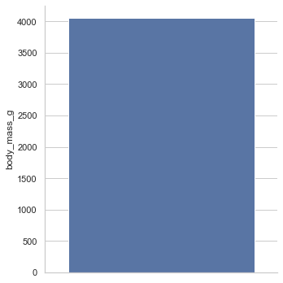

```python
from numpy import median
sns.catplot(kind="bar", data=penguins, y="body_mass_g", estimator=median, ci=None)
plt.show()
```

### Pair & Joint Plot

[output not shown]

**EXAMPLES**

**Pairplot**

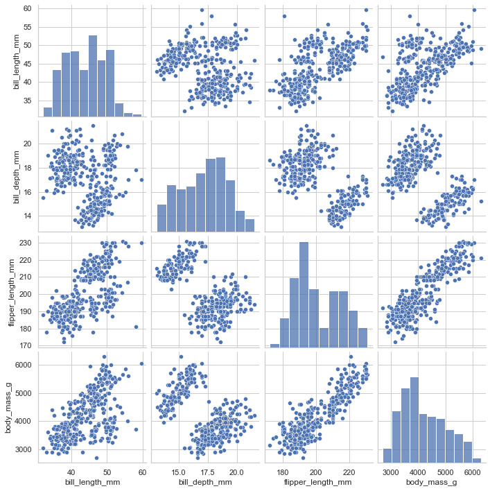

```python
sns.pairplot(penguins)
plt.show()
```

**Pairplot with Hue**

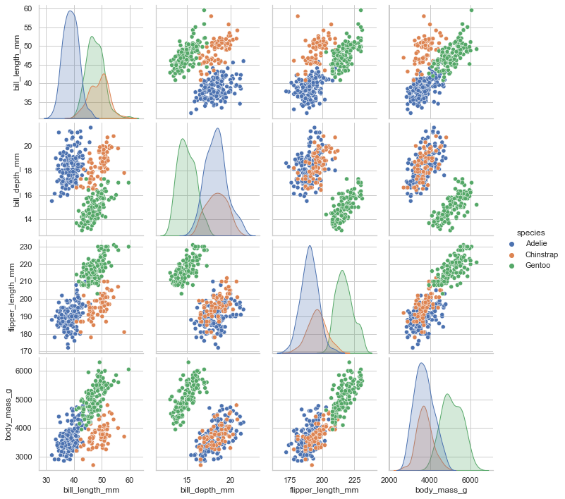

```python
sns.pairplot(penguins, hue="species")
plt.show()
```

**Jointplot**

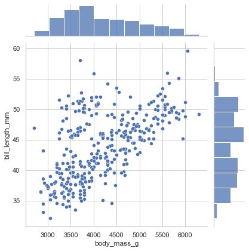

```python
sns.jointplot(data=penguins, x="body_mass_g", y="bill_length_mm")
plt.show()
```

**Jointplot with Hue**

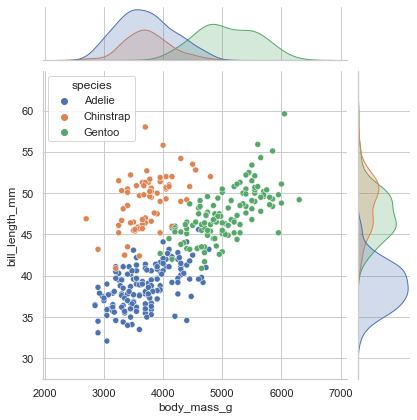

```python
sns.jointplot(data=penguins, x="body_mass_g", y="bill_length_mm", hue="species")
plt.show()
```